# FastEnz_comparison

May Roberts

2025-11-11

# FastEnz comparison

## Setup shop

### Set working environment

Input files you will need: .vcf file (data processing steps output, likely from ipyrad) and a population codes csv (column of pop codes in order of sequences in vcf - more info below).

```r
setwd("/Users/mayroberts/Documents/Projects/FastEnztest/")
```

### Load libraries

```r
library(adegenet)
library(ape)
library(StAMPP)
library(poppr)
library(vcfR)
library(devtools)
library("BiocManager")
library(dartRverse)
```

```r
library(dartR.base)
library(dartR.captive)
library(dartR.data)
library(dartR.popgen)
library(dartR.sim)
library(dartR.spatial)
library(ggplot2)
library(dartR)
```

### Import data:

Here we import the VCF file from ipyrad and then convert to genlight object. Read in the VCF file:

```r
FastEnzTest.vcf <- read.vcfR("/Users/mayroberts/Documents/Projects/FastEnzTest/ipyrad/FastEnz_test_outfiles/FastEnz_test.vcf")
```

```
## Scanning file to determine attributes.
## File attributes:
##   meta lines: 10
##   header_line: 11
##   variant count: 5578
##   column count: 27
## Meta line 10 read in.
## All meta lines processed.
## gt matrix initialized.
## Character matrix gt created.
##   Character matrix gt rows: 5578
##   Character matrix gt cols: 27
##   skip: 0
##   nrows: 5578
##   row_num: 0
## Processed variant 1000Processed variant 2000Processed variant 3000Processed variant 4000Processed variant 5000Processed variant: 5578
## All variants processed
```

```r
FastEnzvsSNI.vcf <- read.vcfR("/Users/mayroberts/Documents/Projects/FastEnztest/ipyrad/FastEnz_only_outfiles/FastEnz_only.vcf")
```

```
## Scanning file to determine attributes.
## File attributes:
##   meta lines: 10
##   header_line: 11
##   variant count: 273
##   column count: 21
## Meta line 10 read in.
## All meta lines processed.
## gt matrix initialized.
## Character matrix gt created.
##   Character matrix gt rows: 273
##   Character matrix gt cols: 21
##   skip: 0
##   nrows: 273
##   row_num: 0
## Processed variant: 273
## All variants processed
```

```r
OrigEnzvsSNI.vcf <- read.vcfR("/Users/mayroberts/Documents/Projects/FastEnztest/ipyrad/OrigEnz_outfiles/OrigEnz.vcf")
```

```
## Scanning file to determine attributes.
## File attributes:
##   meta lines: 10
##   header_line: 11
##   variant count: 209
##   column count: 21
## Meta line 10 read in.
## All meta lines processed.
## gt matrix initialized.
## Character matrix gt created.
##   Character matrix gt rows: 209
##   Character matrix gt cols: 21
##   skip: 0
##   nrows: 209
##   row_num: 0
## Processed variant: 209
## All variants processed
```

```r
FastEnzTest.vcf
```

```
## ***** Object of Class vcfR *****
## 18 samples
## 2232 CHROMs
## 5,578 variants
## Object size: 2.4 Mb
## 0 percent missing data
## *****        *****         *****
```

```r
OrigEnzvsSNI.vcf
```

```
## ***** Object of Class vcfR *****
## 12 samples
## 107 CHROMs
## 209 variants
## Object size: 0.1 Mb
## 0 percent missing data
## *****        *****         *****
```

```r
FastEnzvsSNI.vcf
```

```
## ***** Object of Class vcfR *****
## 12 samples
## 125 CHROMs
## 273 variants
## Object size: 0.2 Mb
## 0 percent missing data
## *****        *****         *****
```

Convert the VCF file to genlight object:  
Name it something easy to find as your genlight object, you will use it many times in the downstream analyses.

```r
gl_FastEnzTest <- vcfR2genlight(FastEnzTest.vcf)
gl_Orig <- vcfR2genlight(OrigEnzvsSNI.vcf)
gl_Fast <- vcfR2genlight(FastEnzvsSNI.vcf)
```

### Import population codes

*Making your popcodes.csv* The column of population codes should be in the same order as the order samples in your output from IPYRAD. Get this from the _stats.txt file in the _outfiles in your ipyrad directory and make the list in excel and a text editor and save as a .csv. It’s important that the order of the pop_codes matches the order of the sample names in the vcf file. Also, no spaces in site names.

Read in population file:

```r
#this file has pop codes in column1 (V1)
pop.data <- read.table("/Users/mayroberts/Documents/Projects/FastEnztest/pop_file.csv")
pop.dataF <- read.table("/Users/mayroberts/Documents/Projects/FastEnztest/pop_file_F.csv")
pop.dataO <- read.table("/Users/mayroberts/Documents/Projects/FastEnztest/pop_file_O.csv")
str(pop.data)
```

```
## 'data.frame':    18 obs. of  2 variables:
##  $ V1: chr  "Lomatium_insulare_10727_GUZA" "Lomatium_insulare_10728_GUZA" "Lomatium_insulare_10729_GUZA" "Lomatium_insulare_10730_GUPS" ...
##  $ V2: chr  "GUorig" "GUorig" "GUorig" "GUorig" ...
```

```r
str(pop.dataF)
```

```
## 'data.frame':    12 obs. of  2 variables:
##  $ V1: chr  "Lomatium_insulare_9900_SNI1" "Lomatium_insulare_9901_SNI1" "Lomatium_insulare_9902_SNI1" "Lomatium_insulare_9917_SNI3" ...
##  $ V2: chr  "SNI" "SNI" "SNI" "SNI" ...
```

```r
str(pop.dataO)
```

```
## 'data.frame':    12 obs. of  2 variables:
##  $ V1: chr  "Lomatium_insulare_10727_GUZA" "Lomatium_insulare_10728_GUZA" "Lomatium_insulare_10729_GUZA" "Lomatium_insulare_10730_GUPS" ...
##  $ V2: chr  "GUorig" "GUorig" "GUorig" "GUorig" ...
```

Add population codes to your genlight object

```r
pop(gl_FastEnzTest) <- pop.data$V2
pop(gl_Fast) <- pop.dataF$V2
pop(gl_Orig) <- pop.dataO$V2
head(gl_FastEnzTest)
```

```
##  /// GENLIGHT OBJECT /////////
##
##  // 6 genotypes,  5,516 binary SNPs, size: 643.1 Kb
##  10208 (30.84 %) missing data
##
##  // Basic content
##    @gen: list of 6 SNPbin
##
##  // Optional content
##    @ind.names:  6 individual labels
##    @loc.names:  5516 locus labels
##    @chromosome: factor storing chromosomes of the SNPs
##    @position: integer storing positions of the SNPs
##    @pop: population of each individual (group size range: 6-6)
##    @other: a list containing: elements without names
```

```r
head(gl_Fast)
```

```
##  /// GENLIGHT OBJECT /////////
##
##  // 6 genotypes,  272 binary SNPs, size: 42.4 Kb
##  88 (5.39 %) missing data
##
##  // Basic content
##    @gen: list of 6 SNPbin
##
##  // Optional content
##    @ind.names:  6 individual labels
##    @loc.names:  272 locus labels
##    @chromosome: factor storing chromosomes of the SNPs
##    @position: integer storing positions of the SNPs
##    @pop: population of each individual (group size range: 6-6)
##    @other: a list containing: elements without names
```

```r
head(gl_Orig)
```

```
##  /// GENLIGHT OBJECT /////////
##
##  // 6 genotypes,  208 binary SNPs, size: 36.2 Kb
##  100 (8.01 %) missing data
##
##  // Basic content
##    @gen: list of 6 SNPbin
##
##  // Optional content
##    @ind.names:  6 individual labels
##    @loc.names:  208 locus labels
##    @chromosome: factor storing chromosomes of the SNPs
##    @position: integer storing positions of the SNPs
##    @pop: population of each individual (group size range: 6-6)
##    @other: a list containing: elements without names
```

## Quick check of data:

### Genlight compliance check

This is run by dartR to make sure that the genlight object conforms to dartR requirements, if it doesn’t, it will rectify it. Can take a minute.

```r
gl_FastEnzTest <- gl.compliance.check(gl_FastEnzTest)
```

```
## Starting gl.compliance.check
##   Processing genlight object with SNP data
##   The slot loc.all, which stores allele name for each locus, is empty.
## Creating a dummy variable (A/C) to insert in this slot.
##   Checking coding of SNPs
##     SNP data scored NA, 0, 1 or 2 confirmed
##   Checking locus metrics and flags
##   Recalculating locus metrics
##   Checking for monomorphic loci
##     No monomorphic loci detected
##   Checking for loci with all missing data
##     No loci with all missing data detected
##   Checking whether individual names are unique.
##   Checking for individual metrics
##   Warning: Creating a slot for individual metrics
##   Checking for population assignments
##     Population assignments confirmed
##   Spelling of coordinates checked and changed if necessary to
##             lat/lon
## Completed: gl.compliance.check
```

```r
gl_Fast <- gl.compliance.check(gl_Fast)
```

```
## Starting gl.compliance.check
##   Processing genlight object with SNP data
##   The slot loc.all, which stores allele name for each locus, is empty.
## Creating a dummy variable (A/C) to insert in this slot.
##   Checking coding of SNPs
##     SNP data scored NA, 0, 1 or 2 confirmed
##   Checking locus metrics and flags
##   Recalculating locus metrics
##   Checking for monomorphic loci
##     No monomorphic loci detected
##   Checking for loci with all missing data
##     No loci with all missing data detected
##   Checking whether individual names are unique.
##   Checking for individual metrics
##   Warning: Creating a slot for individual metrics
##   Checking for population assignments
##     Population assignments confirmed
##   Spelling of coordinates checked and changed if necessary to
##             lat/lon
## Completed: gl.compliance.check
```

```r
gl_Orig <- gl.compliance.check(gl_Orig)
```

```
## Starting gl.compliance.check
##   Processing genlight object with SNP data
##   The slot loc.all, which stores allele name for each locus, is empty.
## Creating a dummy variable (A/C) to insert in this slot.
##   Checking coding of SNPs
##     SNP data scored NA, 0, 1 or 2 confirmed
##   Checking locus metrics and flags
##   Recalculating locus metrics
##   Checking for monomorphic loci
##     No monomorphic loci detected
##   Checking for loci with all missing data
##     No loci with all missing data detected
##   Checking whether individual names are unique.
##   Checking for individual metrics
##   Warning: Creating a slot for individual metrics
##   Checking for population assignments
##     Population assignments confirmed
##   Spelling of coordinates checked and changed if necessary to
##             lat/lon
## Completed: gl.compliance.check
```

### N per island

This counts samples by population and makes and object calls it popvsN

```r
popvsn <-table(pop(gl_FastEnzTest))
popvsn # table of populations and number of samples in them
```

```
##
## GUFast GUorig    SNI
##      6      6      6
```

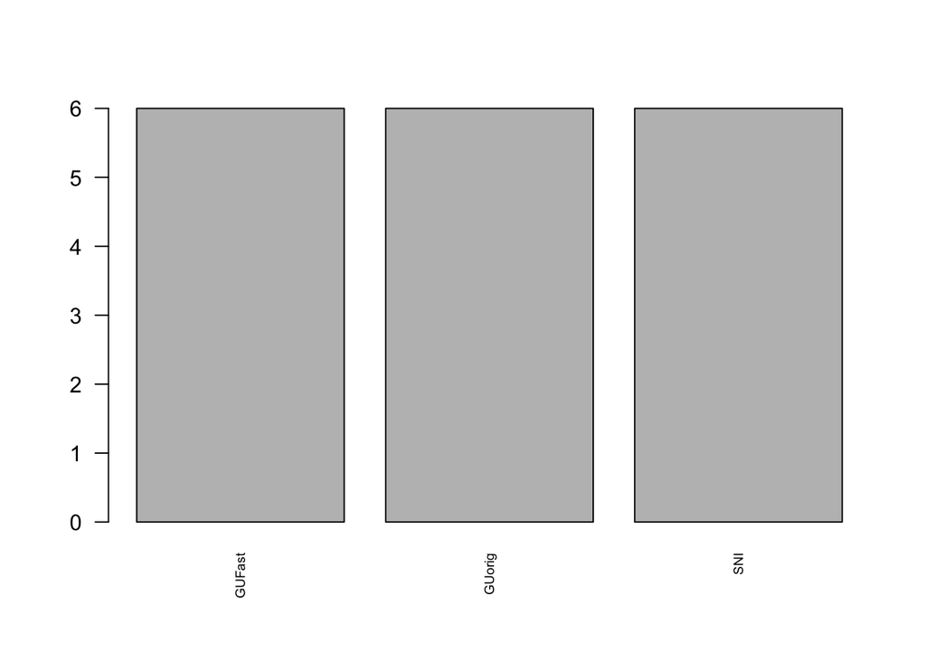

```r
barplot(popvsn, las=2, cex.names = .6) #Barplot of number of samples per population
```

```r
popvsn <-table(pop(gl_Fast))
popvsn # table of populations and number of samples in them
```

```
##
## GUFast    SNI
##      6      6
```

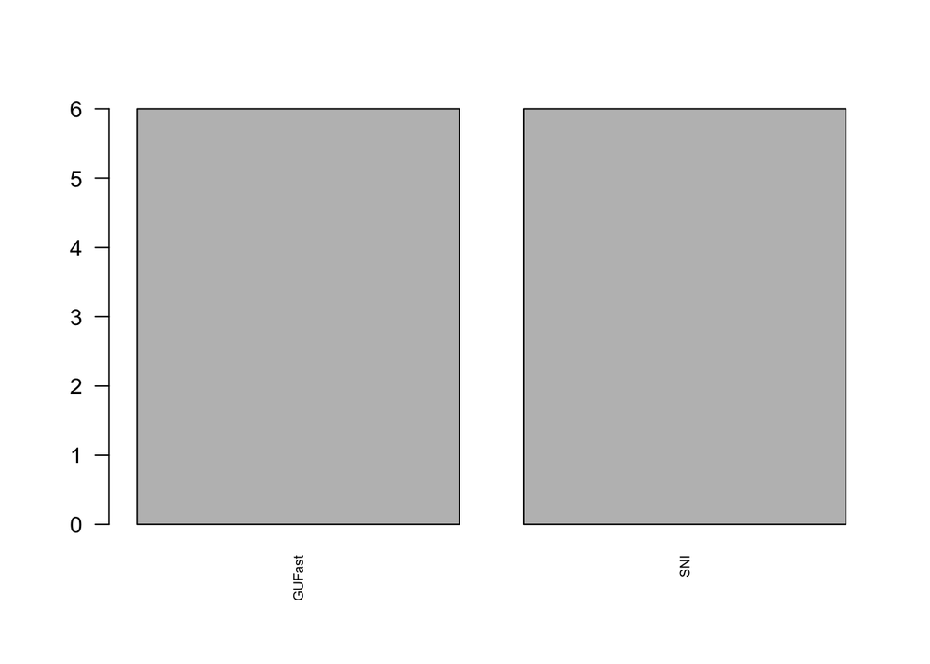

```r
barplot(popvsn, las=2, cex.names = .6) #Barplot of number of samples per population
```

```r
popvsn <-table(pop(gl_Orig))
popvsn # table of populations and number of samples in them
```

```
##
## GUorig    SNI
##      6      6
```

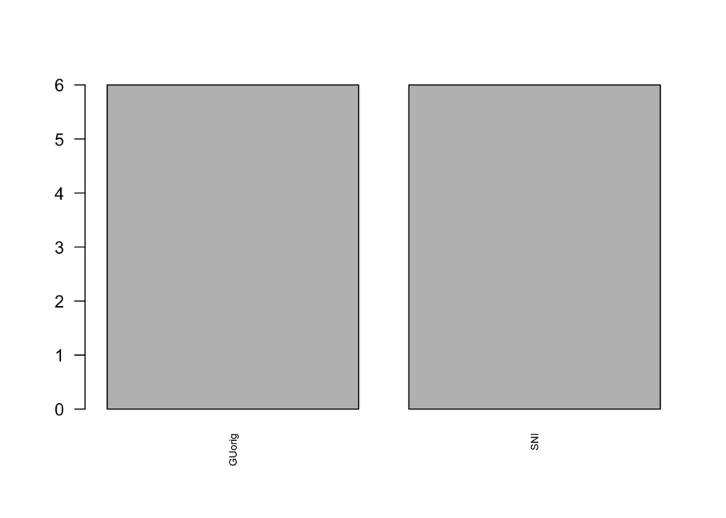

```r
barplot(popvsn, las=2, cex.names = .6) #Barplot of number of samples per population
```

### Assess missing data  
This produces a plot where each sample is in a row down the y axis and loci are across the x. Can take a minute or two depending on number of samples and seqs.

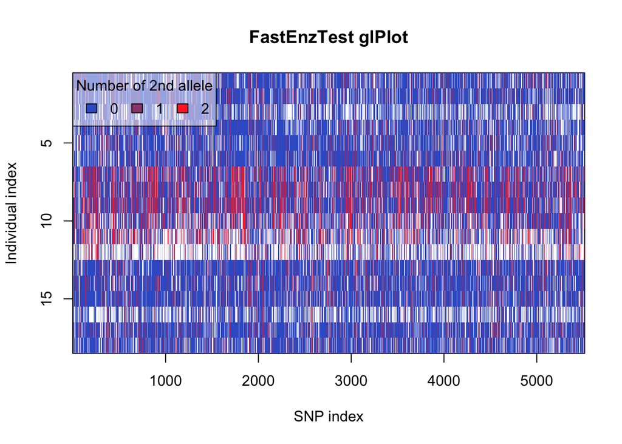

```r
glPlot(gl_FastEnzTest, posi="topleft")
title("FastEnzTest glPlot")
```

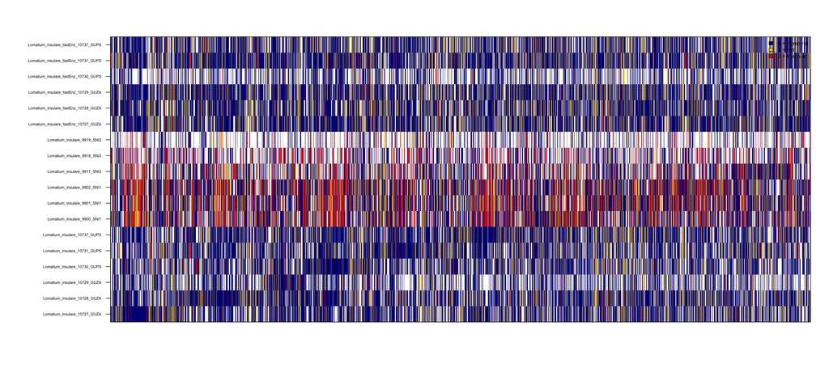

```r
# Convert to matrix
mat <- as.matrix(gl_FastEnzTest)

#Adjust margins: bottom, left, top, right
# Increase left margin (second number) for long sample names
par(mar = c(5, 12, 4, 2))

# Plot the heatmap
image(t(mat), axes = FALSE, col = c("navy", "gold", "red"))

# Add y-axis labels
axis(2, at = seq(0, 1, length.out = nInd(gl_FastEnzTest)),
     labels = indNames(gl_FastEnzTest), las = 2, cex.axis = 0.5)

# Add box around the plot
box()

# Add legend
legend("topright", legend = c("0 = homo ref", "1 = het", "2 = homo alt"),
       fill = c("navy", "gold", "red"), cex = 0.7, bty = "n")
```

Ordered so that pairs of samples are next to each other

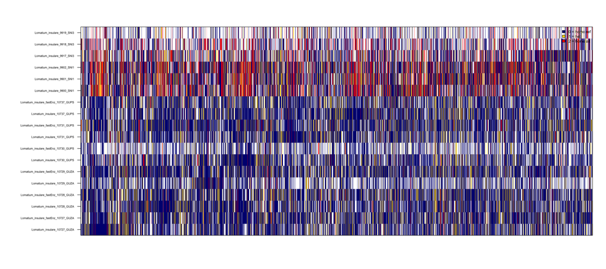

```r
########
# Custom order of sample names
my_order <- c("Lomatium_insulare_10727_GUZA", "Lomatium_insulare_fastEnz_10727_GUZA", "Lomatium_insulare_10728_GUZA", "Lomatium_insulare_fastEnz_10728_GUZA", "Lomatium_insulare_10729_GUZA", "Lomatium_insulare_fastEnz_10729_GUZA", "Lomatium_insulare_10730_GUPS", "Lomatium_insulare_fastEnz_10730_GUPS", "Lomatium_insulare_10731_GUPS", "Lomatium_insulare_fastEnz_10731_GUPS", "Lomatium_insulare_10737_GUPS", "Lomatium_insulare_fastEnz_10737_GUPS","Lomatium_insulare_9900_SNI1", "Lomatium_insulare_9901_SNI1","Lomatium_insulare_9902_SNI1", "Lomatium_insulare_9917_SNI3", "Lomatium_insulare_9918_SNI3", "Lomatium_insulare_9919_SNI3")
# Reorder the genlight object
gl_FastEnzTest_ordered <- gl_FastEnzTest[match(my_order, indNames(gl_FastEnzTest))]

# Convert to matrix
mat <- as.matrix(gl_FastEnzTest_ordered)

#Adjust margins: bottom, left, top, right
# Increase left margin (second number) for long sample names
par(mar = c(5, 12, 4, 2))

# Plot the heatmap
image(t(mat), axes = FALSE, col = c("navy", "gold", "red"))

# Add y-axis labels
axis(2, at = seq(0, 1, length.out = nInd(gl_FastEnzTest_ordered)),
     labels = indNames(gl_FastEnzTest_ordered), las = 2, cex.axis = 0.5)

# Add box around the plot
box()

# Add legend
legend("topright", legend = c("0 = homo ref", "1 = het", "2 = homo alt"),
       fill = c("navy", "gold", "red"), cex = 0.7, bty = "n")
```

## Neighbor joining tree

### NJ tree - colors by site

I recommend running this in the console directly to get saveable plots in the “plots” window. Make sure the plots window is expanded.

```r
library(ape)
#Distance matrix as tre object
tre <- njs(dist(as.matrix(gl_FastEnzTest)))
treF <- njs(dist(as.matrix(gl_Fast)))
treO <- njs(dist(as.matrix(gl_Orig)))
#
```

Plot FastEnz + Orig + SNI together

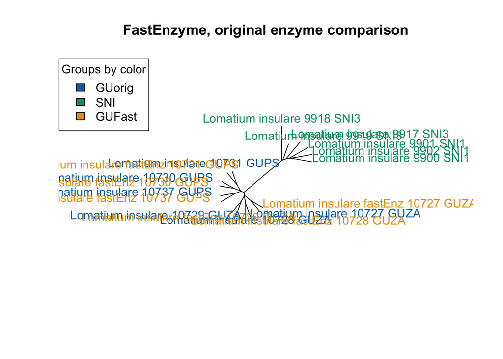

```r
# Define color mapping
pop_levels <- unique(gl_FastEnzTest$pop)  # e.g. c("SNI","GUorig","GUFast")
palette3 <- c("#0072B2","#009E73","#E69F00")  # length must match number of populations
names(palette3) <- pop_levels  # name colors by population

# Map tip colors
tip_colors <- palette3[as.character(gl_FastEnzTest$pop)]

# Plot tree
plot(tre, type="unrooted", show.tip.lab=TRUE, cex=1, font=1, tip.col=tip_colors)

# Add legend (line colors)
legend("topleft", legend = pop_levels,
       col = palette3, cex=1, fill = palette3, title = "Groups by color")
title("FastEnzyme, original enzyme comparison")
```

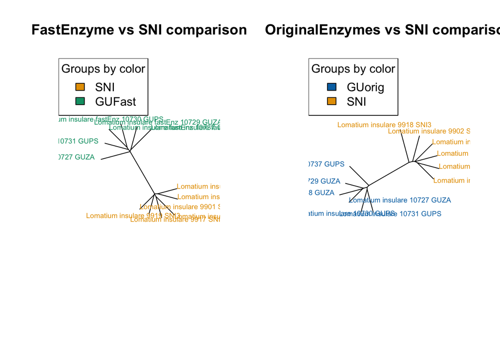

```r
#pdf("Fast_Orig_trees_large.pdf", width = 14, height = 7)  # in inches

# Set up 1 row, 2 columns
par(mfrow = c(1, 2))

## ---- Plot 1: Fast + SNI ----
pop_levels <- unique(gl_Fast$pop)
palette3 <- c("#E69F00","#009E73")
names(palette3) <- pop_levels
tip_colors <- palette3[as.character(gl_Fast$pop)]

plot(treF, type = "unrooted", show.tip.lab = TRUE, cex = .6, font = 1, tip.col = tip_colors)
legend("topleft", legend = pop_levels, fill = palette3, cex = 1, title = "Groups by color")
title("FastEnzyme vs SNI comparison")

## ---- Plot 2: Orig + SNI ----
pop_levels <- unique(gl_Orig$pop)
palette3 <- c("#0072B2","#E69F00")
names(palette3) <- pop_levels
tip_colors <- palette3[as.character(gl_Orig$pop)]

plot(treO, type = "unrooted", show.tip.lab = TRUE, cex = .6, font = 1, tip.col = tip_colors)
legend("topleft", legend = pop_levels, fill = palette3, cex = 1, title = "Groups by color")
title("OriginalEnzymes vs SNI comparison")
```

```r
# Reset layout afterward
par(mfrow = c(1, 1))

#dev.off()
```

## PCA

ran `run_plink.sh` in terminal with LOMINS_GUAD.vcf file

then to visualize:

```r
library(ggplot2)
library(RColorBrewer)
```

# set input variables

read in the output from plink

```r
eigenval=read.table("/Users/mayroberts/Documents/Projects/FastEnztest/plink_PCA/fastEnz.eigenval")
pca=read.table("/Users/mayroberts/Documents/Projects/FastEnztest/plink_PCA/fastEnz.eigenvec")

eigenval_F=read.table("/Users/mayroberts/Documents/Projects/FastEnztest/plink_PCA/fastEnz_F.eigenval")
pca_F=read.table("/Users/mayroberts/Documents/Projects/FastEnztest/plink_PCA/fastEnz_F.eigenvec")

eigenval_O=read.table("/Users/mayroberts/Documents/Projects/FastEnztest/plink_PCA/OrigEnz.eigenval")
pca_O=read.table("/Users/mayroberts/Documents/Projects/FastEnztest/plink_PCA/OrigEnz.eigenvec")
```

Import lists of samples by how you want them colored in your plot. Single column of sample name with no .filetype at ending ### FastEnz+OriginalEnz+SNI PCA plot

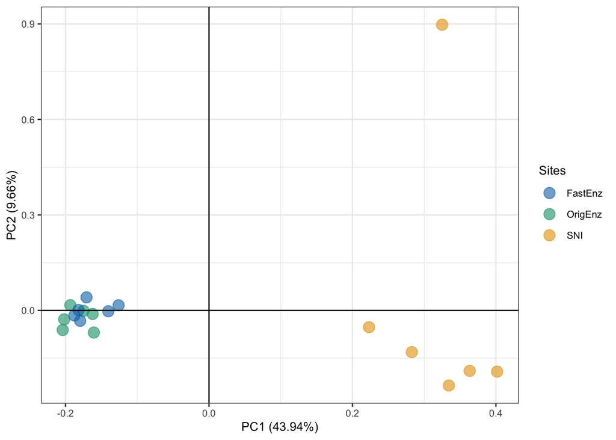

```r
## FastEnz+OriginalEnz+SNI PCA plot
FastEnz=read.table("/Users/mayroberts/Documents/Projects/FastEnztest/plink_PCA/FastEnz.txt")
OrigEnz=read.table("/Users/mayroberts/Documents/Projects/FastEnztest/plink_PCA/OrigEnz.txt")
SNI=read.table("/Users/mayroberts/Documents/Projects/FastEnztest/plink_PCA/SNI.txt")
pca$Sites <- NA  # create empty column first

pca$Sites=ifelse(pca$V1%in%FastEnz$V1,"FastEnz",pca$Sites)
pca$Sites=ifelse(pca$V1%in%OrigEnz$V1,"OrigEnz",pca$Sites)
pca$Sites=ifelse(pca$V1%in%SNI$V1,"SNI",pca$Sites)

cols <- c("#0072B2","#009E73","#E69F00")

### Global plotting controls
dataset_name <- "EnzTest"
jitter_width  <- 0.05
jitter_height <- 0.05
alpha_val     <- 0.6
point_size    <- 4

### Function to plot any two PCs and save to file
plot_pca <- function(df, eigenval, pc_x, pc_y, cols, outdir = ".", format = "pdf") {

  # Build the ggplot object
  p <- ggplot(df, aes_string(x = paste0("V", pc_x+2), y = paste0("V", pc_y+2), colour = "Sites")) +
    geom_jitter(width = jitter_width, height = jitter_height, alpha = alpha_val, size = point_size) +
    scale_color_manual(values = cols) +
    geom_hline(yintercept = 0) +
    geom_vline(xintercept = 0) +
    theme_bw() +
    labs(
      x = paste0("PC", pc_x, " (", round(100 * eigenval[pc_x,1] / sum(eigenval[,1]), 2), "%)"),
      y = paste0("PC", pc_y, " (", round(100 * eigenval[pc_y,1] / sum(eigenval[,1]), 2), "%)")
    ) +
    theme(text = element_text(size = 10))

  # Construct filename
  filename <- file.path(outdir, paste0(dataset_name,"_PC", pc_x, "_PC", pc_y, ".", format))

  # Save depending on chosen format
  if (format == "pdf") {
    ggsave(filename, plot = p, device = "pdf", width = 6, height = 5)
  } else if (format == "png") {
    ggsave(filename, plot = p, device = "png", width = 6, height = 5, dpi = 300)
  } else {
    warning("Unsupported format. Use 'pdf' or 'png'.")
  }

  # Also return plot to R session
  return(p)
}

### plots
# Save to PDF (default) in current working directory
plot_pca(pca, eigenval, 1, 2, cols)    # PC1 vs PC2
```

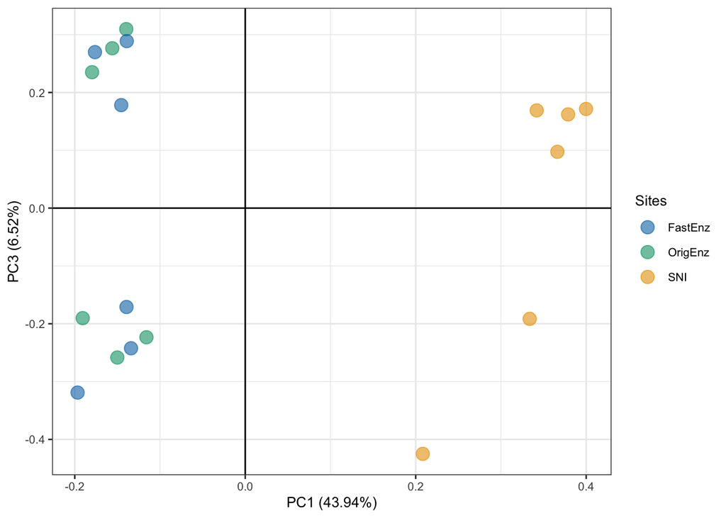

```r
plot_pca(pca, eigenval, 1, 3, cols)    # PC1 vs PC3
```

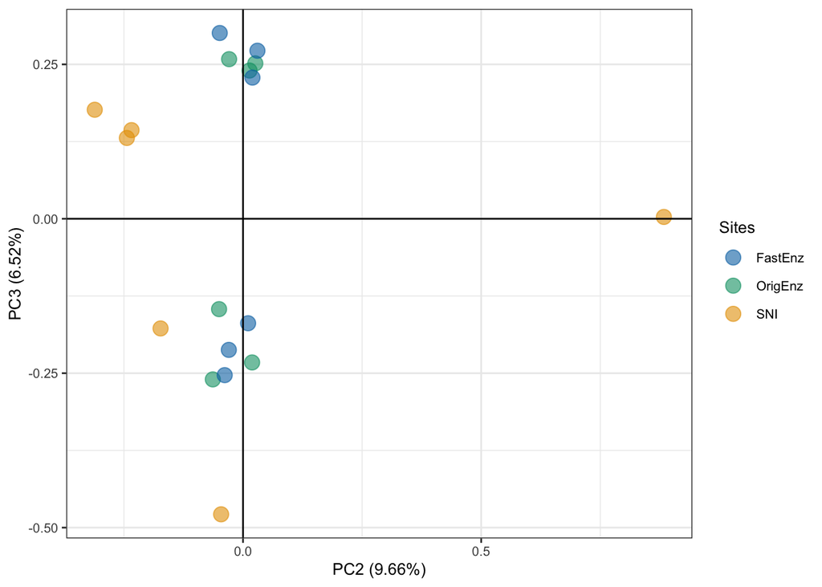

```r
#plot_pca(pca, eigenval, 1, 4, cols)    # PC1 vs PC4
#plot_pca(pca, eigenval, 1, 5, cols)    # PC1 vs PC5
#plot_pca(pca, eigenval, 1, 6, cols)    # PC1 vs PC6
plot_pca(pca, eigenval, 2, 3, cols)    # PC2 vs PC3
```

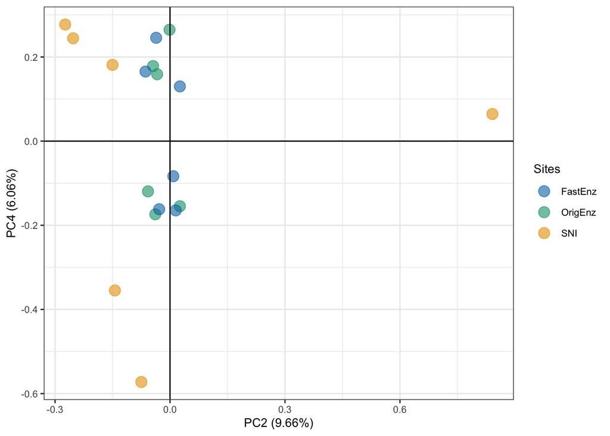

```r
plot_pca(pca, eigenval, 2, 4, cols)    # PC2 vs PC4
```

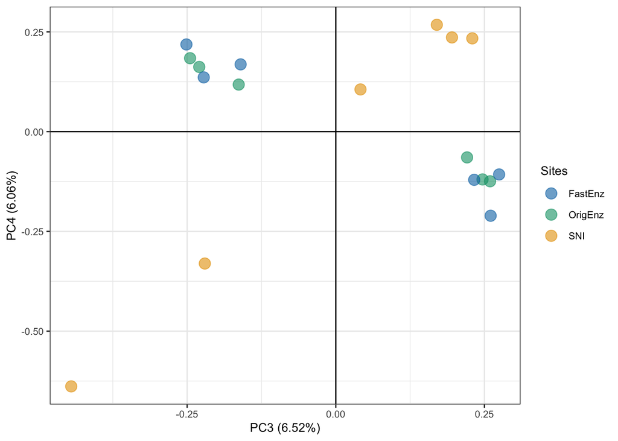

```r
#plot_pca(pca, eigenval, 2, 5, cols)    # PC2 vs PC5
#plot_pca(pca, eigenval, 2, 6, cols)    # PC2 vs PC6
plot_pca(pca, eigenval, 3, 4, cols)    # PC3 vs PC4
```

```r
#plot_pca(pca, eigenval, 3, 5, cols)    # PC3 vs PC5
#plot_pca(pca, eigenval, 3, 6, cols)    # PC3 vs PC6


# Save to PNG in a specific folder
#plot_pca(pca, eigenval, 1, 2, cols, outdir = "/Users/mayroberts/Documents/Projects/LOMINS/Analysis/plink/PCA_locin25psampls/plots", format = "png")
```

### FastEnz only + SNI PCA plot

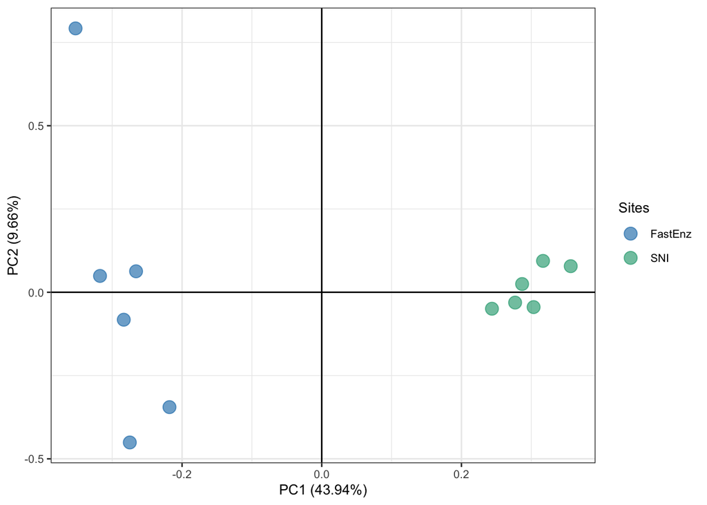

```r
## FastEnz only + SNI PCA plot
FastEnz=read.table("/Users/mayroberts/Documents/Projects/FastEnztest/plink_PCA/FastEnz.txt")
SNI=read.table("/Users/mayroberts/Documents/Projects/FastEnztest/plink_PCA/SNI.txt")
pca_F$Sites <- NA  # create empty column first

pca_F$Sites=ifelse(pca_F$V1%in%FastEnz$V1,"FastEnz",pca_F$Sites)
pca_F$Sites=ifelse(pca_F$V1%in%SNI$V1,"SNI",pca_F$Sites)

cols <- c("#0072B2","#009E73","#E69F00")

### Global plotting controls
dataset_name <- "Fast"
jitter_width  <- 0.05
jitter_height <- 0.05
alpha_val     <- 0.6
point_size    <- 4

### Function to plot any two PCs and save to file
plot_pca <- function(df, eigenval, pc_x, pc_y, cols, outdir = ".", format = "pdf") {

  # Build the ggplot object
  p <- ggplot(df, aes_string(x = paste0("V", pc_x+2), y = paste0("V", pc_y+2), colour = "Sites")) +
    geom_jitter(width = jitter_width, height = jitter_height, alpha = alpha_val, size = point_size) +
    scale_color_manual(values = cols) +
    geom_hline(yintercept = 0) +
    geom_vline(xintercept = 0) +
    theme_bw() +
    labs(
      x = paste0("PC", pc_x, " (", round(100 * eigenval[pc_x,1] / sum(eigenval[,1]), 2), "%)"),
      y = paste0("PC", pc_y, " (", round(100 * eigenval[pc_y,1] / sum(eigenval[,1]), 2), "%)")
    ) +
    theme(text = element_text(size = 10))

  # Construct filename
  filename <- file.path(outdir, paste0(dataset_name,"_PC", pc_x, "_PC", pc_y, ".", format))

  # Save depending on chosen format
  if (format == "pdf") {
    ggsave(filename, plot = p, device = "pdf", width = 6, height = 5)
  } else if (format == "png") {
    ggsave(filename, plot = p, device = "png", width = 6, height = 5, dpi = 300)
  } else {
    warning("Unsupported format. Use 'pdf' or 'png'.")
  }

  # Also return plot to R session
  return(p)
}

### plots
# Save to PDF (default) in current working directory
plot_pca(pca_F, eigenval, 1, 2, cols)    # PC1 vs PC2
```

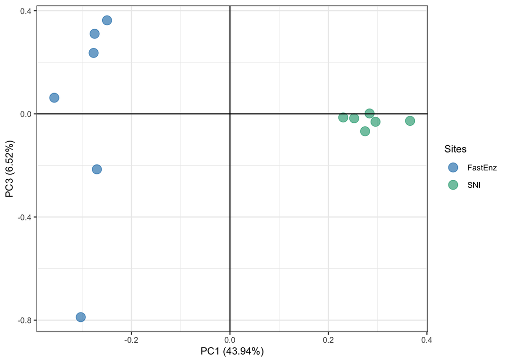

```r
plot_pca(pca_F, eigenval, 1, 3, cols)    # PC1 vs PC3
```

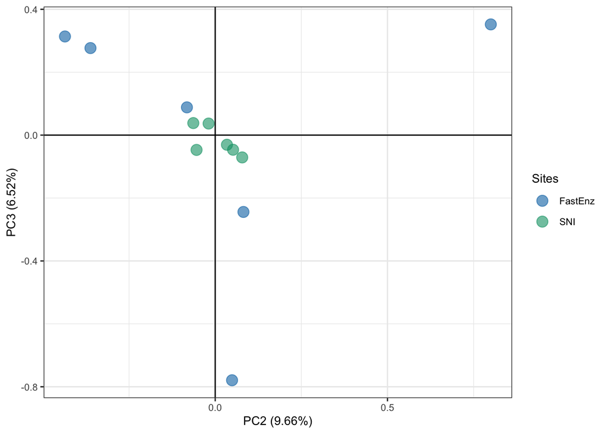

```r
#plot_pca(pca, eigenval, 1, 4, cols)    # PC1 vs PC4
#plot_pca(pca, eigenval, 1, 5, cols)    # PC1 vs PC5
#plot_pca(pca, eigenval, 1, 6, cols)    # PC1 vs PC6
plot_pca(pca_F, eigenval, 2, 3, cols)    # PC2 vs PC3
```

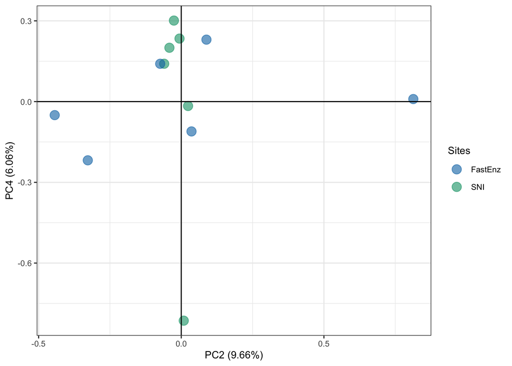

```r
plot_pca(pca_F, eigenval, 2, 4, cols)    # PC2 vs PC4
```

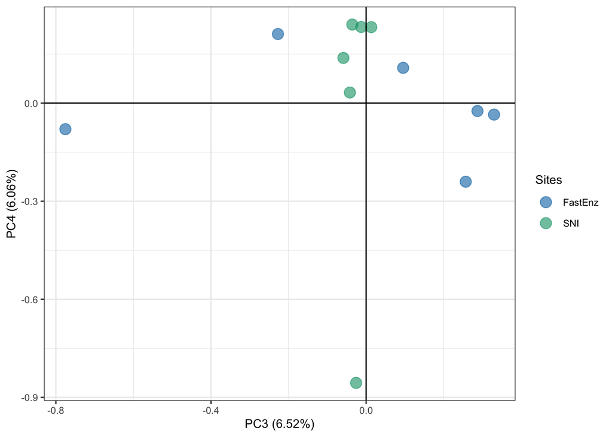

```r
#plot_pca(pca, eigenval, 2, 5, cols)    # PC2 vs PC5
#plot_pca(pca, eigenval, 2, 6, cols)    # PC2 vs PC6
plot_pca(pca_F, eigenval, 3, 4, cols)    # PC3 vs PC4
```

```r
#plot_pca(pca, eigenval, 3, 5, cols)    # PC3 vs PC5
#plot_pca(pca, eigenval, 3, 6, cols)    # PC3 vs PC6


# Save to PNG in a specific folder
#plot_pca(pca, eigenval, 1, 2, cols, outdir = "/Users/mayroberts/Documents/Projects/LOMINS/Analysis/plink/PCA_locin25psampls/plots", format = "png")
```

### OrigEnz only + SNI PCA plot

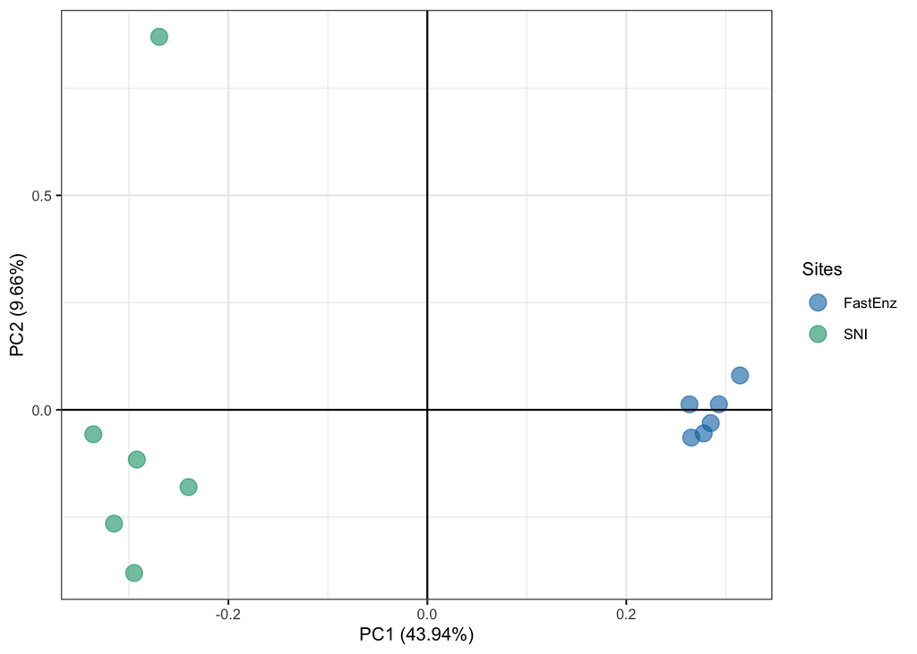

```r
## FastEnz only + SNI PCA plot
OrigEnz=read.table("/Users/mayroberts/Documents/Projects/FastEnztest/plink_PCA/OrigEnz.txt")
SNI=read.table("/Users/mayroberts/Documents/Projects/FastEnztest/plink_PCA/SNI.txt")
pca_O$Sites <- NA  # create empty column first

pca_O$Sites=ifelse(pca_O$V1%in%OrigEnz$V1,"FastEnz",pca_O$Sites)
pca_O$Sites=ifelse(pca_O$V1%in%SNI$V1,"SNI",pca_O$Sites)

cols <- c("#0072B2","#009E73","#E69F00")

### Global plotting controls
dataset_name <- "Fast"
jitter_width  <- 0.05
jitter_height <- 0.05
alpha_val     <- 0.6
point_size    <- 4

### Function to plot any two PCs and save to file
plot_pca <- function(df, eigenval, pc_x, pc_y, cols, outdir = ".", format = "pdf") {

  # Build the ggplot object
  p <- ggplot(df, aes_string(x = paste0("V", pc_x+2), y = paste0("V", pc_y+2), colour = "Sites")) +
    geom_jitter(width = jitter_width, height = jitter_height, alpha = alpha_val, size = point_size) +
    scale_color_manual(values = cols) +
    geom_hline(yintercept = 0) +
    geom_vline(xintercept = 0) +
    theme_bw() +
    labs(
      x = paste0("PC", pc_x, " (", round(100 * eigenval[pc_x,1] / sum(eigenval[,1]), 2), "%)"),
      y = paste0("PC", pc_y, " (", round(100 * eigenval[pc_y,1] / sum(eigenval[,1]), 2), "%)")
    ) +
    theme(text = element_text(size = 10))

  # Construct filename
  filename <- file.path(outdir, paste0(dataset_name,"_PC", pc_x, "_PC", pc_y, ".", format))

  # Save depending on chosen format
  if (format == "pdf") {
    ggsave(filename, plot = p, device = "pdf", width = 6, height = 5)
  } else if (format == "png") {
    ggsave(filename, plot = p, device = "png", width = 6, height = 5, dpi = 300)
  } else {
    warning("Unsupported format. Use 'pdf' or 'png'.")
  }

  # Also return plot to R session
  return(p)
}

### plots
# Save to PDF (default) in current working directory
plot_pca(pca_O, eigenval, 1, 2, cols)    # PC1 vs PC2
```

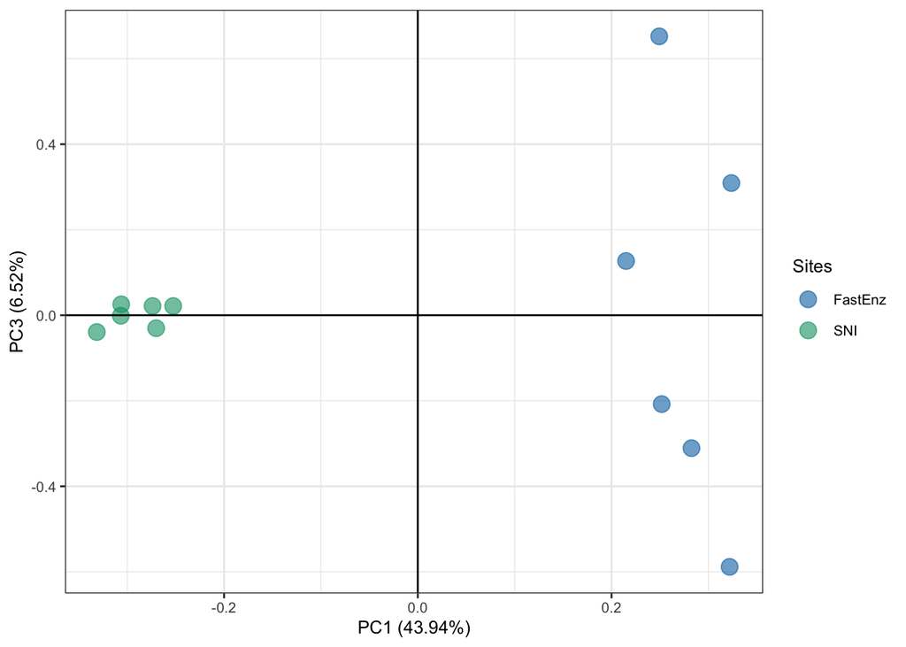

```r
plot_pca(pca_O, eigenval, 1, 3, cols)    # PC1 vs PC3
```

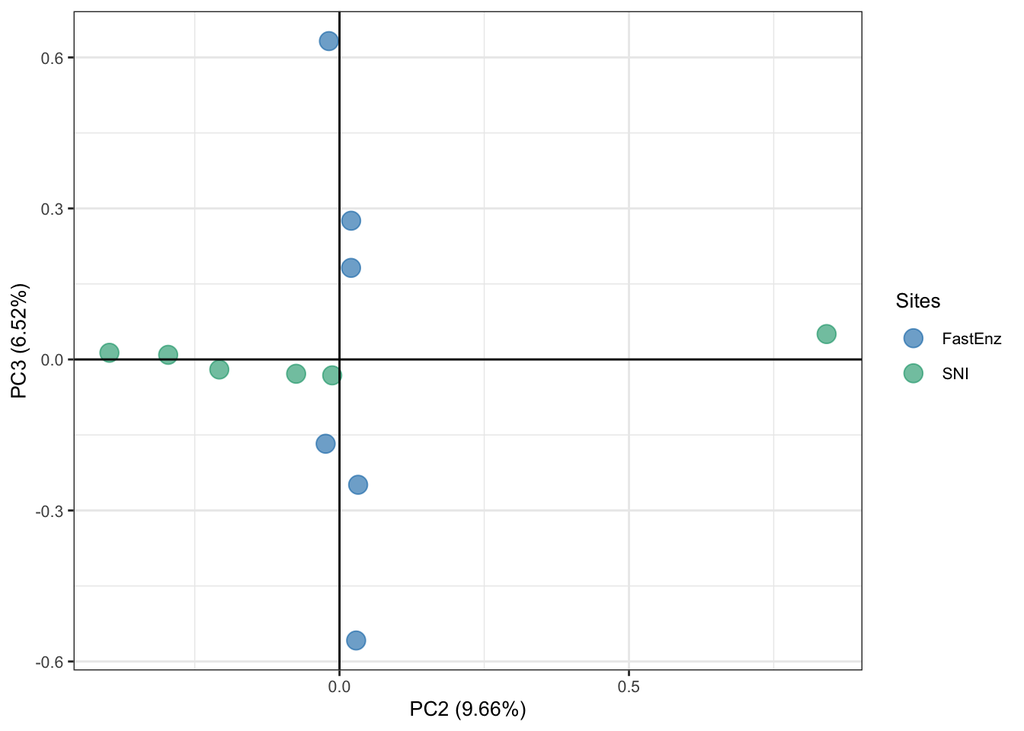

```r
#plot_pca(pca, eigenval, 1, 4, cols)    # PC1 vs PC4
#plot_pca(pca, eigenval, 1, 5, cols)    # PC1 vs PC5
#plot_pca(pca, eigenval, 1, 6, cols)    # PC1 vs PC6
plot_pca(pca_O, eigenval, 2, 3, cols)    # PC2 vs PC3
```

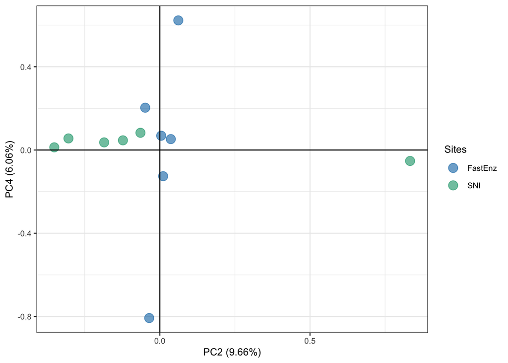

```r
plot_pca(pca_O, eigenval, 2, 4, cols)    # PC2 vs PC4
```

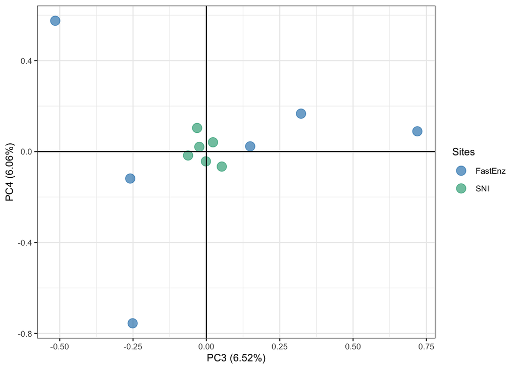

```r
#plot_pca(pca, eigenval, 2, 5, cols)    # PC2 vs PC5
#plot_pca(pca, eigenval, 2, 6, cols)    # PC2 vs PC6
plot_pca(pca_O, eigenval, 3, 4, cols)    # PC3 vs PC4
```

```r
#plot_pca(pca, eigenval, 3, 5, cols)    # PC3 vs PC5
#plot_pca(pca, eigenval, 3, 6, cols)    # PC3 vs PC6


# Save to PNG in a specific folder
#plot_pca(pca, eigenval, 1, 2, cols, outdir = "/Users/mayroberts/Documents/Projects/LOMINS/Analysis/plink/PCA_locin25psampls/plots", format = "png")
```

## Population stats

### Calculate Nei’D

```r
stamppNeisD(gl_FastEnzTest, pop = TRUE)
```

```
##            [,1]     [,2]     [,3]
## GUorig 0.000000 0.372777 0.028816
## SNI    0.372777 0.000000 0.353807
## GUFast 0.028816 0.353807 0.000000
```

### Calculate Fst

```r
stamppFst(gl_FastEnzTest, nboots = 100, percent = 95, nclusters = 1)
```

```
## $Fsts
##           GUorig       SNI GUFast
## GUorig        NA        NA     NA
## SNI    0.6230037        NA     NA
## GUFast 0.0142895 0.5996783     NA
##
## $Pvalues
##        GUorig SNI GUFast
## GUorig     NA  NA     NA
## SNI      0.00  NA     NA
## GUFast   0.01   0     NA
##
## $Bootstraps
##   Population1 Population2            1            2           3           4
## 1      GUorig         SNI  0.607819354 0.6102086198 0.610711931 0.611042084
```

[output cut: 62 more lines]